# Assignment 3: Machine Learning

# Section 2

## Section 2.1

```r
set.seed(42)
csvF<-read.csv(file ="40293751_features.csv" ,header = TRUE)
#kNeighbourMat<-Matrix(csvF[1:8,3])

kNeighbourMat=csvF[csvF$label %in% c('a','j','sad','smiley','xclaim'),]
kNeighbourMat$dummy.class[kNeighbourMat$label %in% c('a','j')]<-"letter"
kNeighbourMat$dummy.class[kNeighbourMat$label=="sad"]<-"sad"
kNeighbourMat$dummy.class[kNeighbourMat$label=="smiley"]<-"smiley"
kNeighbourMat$dummy.class[kNeighbourMat$label=="xclaim"]<-"xclaim"
train.X = cbind(kNeighbourMat$no_neigh_right,kNeighbourMat$aspect_ratio,kNeighbourMat$no_neigh_above,kNeighbourMat$connected_areas)

ks = c(1,3,5,7,9,11,13)
accuracies = c()
for (kk in ks){

  if (kk / 2 !=0)

    {
    print(kk)
    knn1=knn(train.X,train.X,kNeighbourMat$dummy.class,k=kk)
  print(table(knn1,kNeighbourMat$dummy.class))
  accuracies = cbind(accuracies, mean(knn1==kNeighbourMat$dummy.class))
  }
}
```

```
[1] 1

knn1     letter sad smiley xclaim
  letter     16   0      0      0
  sad         0  20      0      0
  smiley      0   0     20      0
  xclaim      0   0      0     20
[1] 3

knn1     letter sad smiley xclaim
  letter     16   0      0      1
  sad         0  17      5      2
  smiley      0   3     15      0
  xclaim      0   0      0     17
[1] 5

knn1     letter sad smiley xclaim
  letter     16   0      0      2
  sad         0  15      4      2
  smiley      0   5     16      0
  xclaim      0   0      0     16
[1] 7

knn1     letter sad smiley xclaim
  letter     16   0      0      3
  sad         0  15      8      1
  smiley      0   5     12      0
  xclaim      0   0      0     16
[1] 9

knn1     letter sad smiley xclaim
  letter     16   0      0      3
  sad         0  15      7      1
  smiley      0   5     13      1
  xclaim      0   0      0     15
[1] 11

knn1     letter sad smiley xclaim
  letter     14   0      0      3
  sad         0  15      9      2
  smiley      0   5     11      0
  xclaim      2   0      0     15
[1] 13

knn1     letter sad smiley xclaim
  letter     14   0      0      3
  sad         0  14      9      2
  smiley      0   5     10      0
  xclaim      2   1      1     15
```

```r
accuracies
```

```
     [,1]      [,2]      [,3]      [,4]      [,5]      [,6]
[1,]    1 0.8552632 0.8289474 0.7763158 0.7763158 0.7236842
          [,7]
[1,] 0.6973684
```

For 2.1 I perform 4 way knn classification, for letter (only a or j), sad, smiley or xclaim using 4 features, which were no_neigh_right,aspect_ratio, no_neigh_above and connected_areas. I chose these features because in assignment 2 these were some of the best features to distinguish between a letter and non letter, and to add these features have similarities between each class e.g. aspect ratio the letters have low values for, while sad is mostly just above 1, xclaim very low values below 0.4 and smiley similar to sad but got more values below 1 and still a lot higher than xclaim and the letters. To distingish between each class, I have set up a dummy.class feature which says in english what class it belongs out of from the 4. I then performed a for loop, taking every number from 1 to 13 and doing if statement to check if it dividing this number by 2 doesn’t give 0, if It doesn’t it is a odd number and is needed for analysis. I then pass my data frame with the 4 features into knn function for both training and test and the dummy.class field and the value of k. The accuracies of each knn would be number of images (76) divided by total number that are correct classification. Above you can see the knn score for each odd value between 1 and 13, as you can see the bigger the k value the worse the accuracy gets, with 1 being a perfect accuracy, getting each classification right. As the k value increases, the training error also increases, this is increase bias because it has to consider more neighbours therefore, the model becomes more complex, as there is no testing data, when k=1 the training data becomes equal to testing data set, therefore 100% correct , as the model becomes more complex it doesn’t do this therefore the accuracies decrease as the k value increases.

## Section 2.2

```r
kfoldsk=5
kNeighbourMat=kNeighbourMat

kNeighbourMat<-kNeighbourMat[sample(nrow(kNeighbourMat)),]
kNeighbourMat$folds<- cut(seq(1,nrow(kNeighbourMat)),breaks=kfoldsk,labels=FALSE)

kNeighbourMat<-kNeighbourMat[sample(nrow(kNeighbourMat)),]
kNeighbourMat$folds <- cut(seq(1,nrow(kNeighbourMat)),breaks=kfoldsk,labels=FALSE)
train_control <- trainControl(method="cv", number=kfoldsk)

tune_grid <- expand.grid(k = ((1:7)*2) -1)


# train the model

model <- train(dummy.class~no_neigh_right+aspect_ratio+no_neigh_above+connected_areas, data=kNeighbourMat,
               trControl=train_control, tuneGrid=tune_grid, method="knn")
# summarize results
print(model)
```

```
k-Nearest Neighbors

76 samples
 4 predictor
 4 classes: 'letter', 'sad', 'smiley', 'xclaim'

No pre-processing
Resampling: Cross-Validated (5 fold)
Summary of sample sizes: 60, 61, 61, 61, 61
Resampling results across tuning parameters:

  k   Accuracy   Kappa
   1  0.7091667  0.6122930
   3  0.6975000  0.5964004
   5  0.6175000  0.4916618
   7  0.6308333  0.5071905
   9  0.6441667  0.5257873
  11  0.6308333  0.5079314
  13  0.6958333  0.5947355

Accuracy was used to select the optimal model using
 the largest value.
The final value used for the model was k = 1.
```

For 2.2 I performed k-nearest-neighbour classification for all odd values between 1 and 13 using 5 fold cross validation for the 4 classes used in 2.1. This would give a better indication on how this data can be fitted as 5 fold cross validation gives us a better indication on how the data is trained and used on unseen data, unlike in 2.1. As expected the accuaries are different from 2.1 and have all decreased from the knn which used the same data as training and test data. Again the best value of K is 1, with accuracy 0.7091667, there is a similar pattern as seen in 2.1, with the higher the k value the lower the accuracy, this is because as the k value becomes bigger the model becomes too generalized and fails to accurately predict data points in both train and test sets, this is known as underfitting (except from k=13), the lower values have also decreased massively on accuracy because of overfitting, e.g. k=1 had accuracy of 1 for 2.1 but it is 0.7091667, this is because the model is too specific and fails to be to generalize,The model accomplishes a high accuracy on train set but will be a poor predictor on new, previously unseen data points, based off our accuracies this is shown to be true. (rest of analysis at 2.4 with graphs).

## Section 2.3

```r
tune_grid<- expand.grid(k = 1)#best value of k
newModel<-train(dummy.class~no_neigh_right+aspect_ratio+no_neigh_above+connected_areas, data=kNeighbourMat,
                trControl=train_control, tuneGrid=tune_grid, method="knn")
knnPredict<-predict(newModel,newdata=kNeighbourMat)
ActualData <- as.factor(kNeighbourMat[["dummy.class"]])
cm=confusionMatrix(knnPredict,ActualData)
cm
```

```
Confusion Matrix and Statistics

          Reference
Prediction letter sad smiley xclaim
    letter     16   0      0      0
    sad         0  20      0      0
    smiley      0   0     20      0
    xclaim      0   0      0     20

Overall Statistics

               Accuracy : 1
                 95% CI : (0.9526, 1)
    No Information Rate : 0.2632
    P-Value [Acc > NIR] : < 2.2e-16

                  Kappa : 1

 Mcnemar's Test P-Value : NA

Statistics by Class:

                     Class: letter Class: sad Class: smiley
Sensitivity                 1.0000     1.0000        1.0000
Specificity                 1.0000     1.0000        1.0000
Pos Pred Value              1.0000     1.0000        1.0000
Neg Pred Value              1.0000     1.0000        1.0000
Prevalence                  0.2105     0.2632        0.2632
Detection Rate              0.2105     0.2632        0.2632
Detection Prevalence        0.2105     0.2632        0.2632
Balanced Accuracy           1.0000     1.0000        1.0000
                     Class: xclaim
Sensitivity                 1.0000
Specificity                 1.0000
Pos Pred Value              1.0000
Neg Pred Value              1.0000
Prevalence                  0.2632
Detection Rate              0.2632
Detection Prevalence        0.2632
Balanced Accuracy           1.0000
```

```r
tune_grid<- expand.grid(k = 3)# next best value of k
newModel<-train(dummy.class~no_neigh_right+aspect_ratio+no_neigh_above+connected_areas, data=kNeighbourMat,
                trControl=train_control, tuneGrid=tune_grid, method="knn")
knnPredict<-predict(newModel,newdata=kNeighbourMat)
ActualData <- as.factor(kNeighbourMat[["dummy.class"]])
cm=confusionMatrix(knnPredict,ActualData)
cm
```

```
Confusion Matrix and Statistics

          Reference
Prediction letter sad smiley xclaim
    letter     16   0      0      1
    sad         0  17      5      2
    smiley      0   3     15      0
    xclaim      0   0      0     17

Overall Statistics

               Accuracy : 0.8553
                 95% CI : (0.7558, 0.9255)
    No Information Rate : 0.2632
    P-Value [Acc > NIR] : < 2.2e-16

                  Kappa : 0.8067

 Mcnemar's Test P-Value : NA

Statistics by Class:

                     Class: letter Class: sad Class: smiley
Sensitivity                 1.0000     0.8500        0.7500
Specificity                 0.9833     0.8750        0.9464
Pos Pred Value              0.9412     0.7083        0.8333
Neg Pred Value              1.0000     0.9423        0.9138
Prevalence                  0.2105     0.2632        0.2632
Detection Rate              0.2105     0.2237        0.1974
Detection Prevalence        0.2237     0.3158        0.2368
Balanced Accuracy           0.9917     0.8625        0.8482
                     Class: xclaim
Sensitivity                 0.8500
Specificity                 1.0000
Pos Pred Value              1.0000
Neg Pred Value              0.9492
Prevalence                  0.2632
Detection Rate              0.2237
Detection Prevalence        0.2237
Balanced Accuracy           0.9250
```

```r
#2.4
x1<-model$results$k
y1<-model$results$Accuracy
y2<-accuracies

ks<-c(1,1/3,1/5,1/7,1/9,1/11,1/13)
plot(ks,y1,type="o",ylim=c(0,1),col="blue",ylab="accuracy rate",xlab="1/k")
lines(ks,type="o",y2,col="red")
```

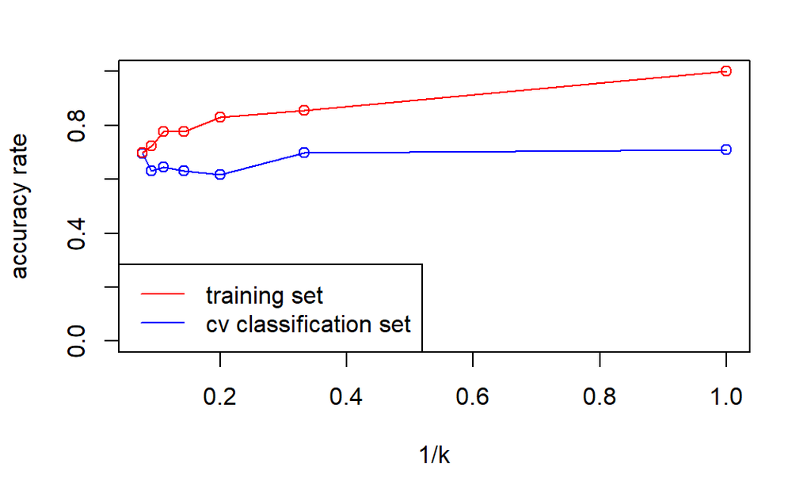

```r
legend(x = "bottomleft",
       legend = c("training set", "cv classification set"),lty = c(1, 1),col=c("red","blue"))
```

```r
NA
NA
```

The graph above shows the comparison between accuracy rate over training data (from 2.1) and cv classication (from 2.2). It shows that no accuries are bigger for cross validation, but there values better reflect the dataset because there is less bias and is used on unseen data unlike training set.

This graph shows what I described in 2.2, that the high k values (ones on the left side of graph are underfitted), as being top left in the graph shows underfitting and lower values overfitted as k values with top right plots in graph show overfitting.

# Section 3

## Section 3.1

```r
set.seed(42)
allFeats<-read.delim(file ="all_features.csv" ,header = F)

allFeats <- allFeats[sample(nrow(allFeats)),]
allFeats$folds <- cut(seq(1,nrow(allFeats)),breaks=kfoldsk,labels=FALSE)
allFeats$folds
```

[output not shown]

[output cut: 22 more lines]

```r
train_control<-trainControl(method = "cv",number = 5,search = 'grid')
tune_grid <-expand.grid( .mtry=c(2,4,6,8))

x=25
results<-matrix(,ncol = 4,byrow = T)



model<-train(V1 ~V3+V4+V5+V6+V7+V8+V9+V10+V11+V12+V13+V14+V15+V16+V17+V18,data=allFeats,method="rf",trControl=train_control,   tuneGrid=tune_grid,ntree=x)
print(model)
```

```
Random Forest

1300 samples
  16 predictor
  13 classes: 'a', 'b', 'c', 'd', 'e', 'f', 'g', 'h', 'i', 'j', 'sad', 'smiley', 'xclaim'

No pre-processing
Resampling: Cross-Validated (5 fold)
Summary of sample sizes: 1040, 1040, 1040, 1040, 1040
Resampling results across tuning parameters:

  mtry  Accuracy   Kappa
  2     0.7638462  0.7441667
  4     0.7700000  0.7508333
  6     0.7869231  0.7691667
  8     0.7723077  0.7533333

Accuracy was used to select the optimal model using
 the largest value.
The final value used for the model was mtry = 6.
```

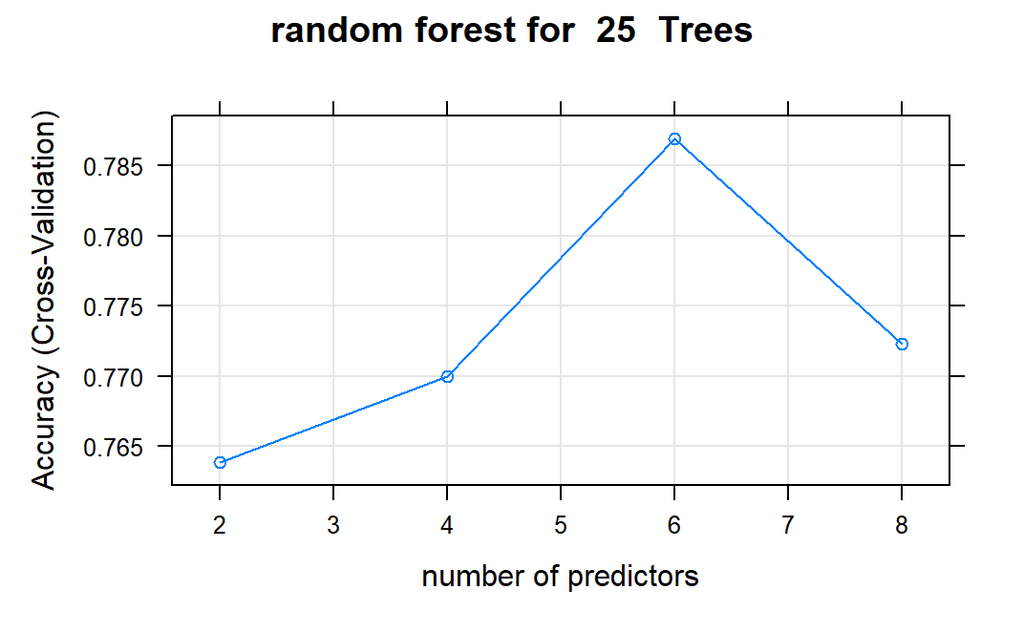

```r
results<-rbind(results,model$results$Accuracy)

plot((model),main=paste("random forest for ",x," Trees"),xlab="number of predictors")
```

```
[1] 75
Random Forest

1300 samples
  16 predictor
  13 classes: 'a', 'b', 'c', 'd', 'e', 'f', 'g', 'h', 'i', 'j', 'sad', 'smiley', 'xclaim'

No pre-processing
Resampling: Cross-Validated (5 fold)
Summary of sample sizes: 1040, 1040, 1040, 1040, 1040
Resampling results across tuning parameters:

  mtry  Accuracy   Kappa
  2     0.7930769  0.7758333
  4     0.8023077  0.7858333
  6     0.8076923  0.7916667
  8     0.8000000  0.7833333

Accuracy was used to select the optimal model using
 the largest value.
The final value used for the model was mtry = 6.
[1] 125
Random Forest

1300 samples
  16 predictor
  13 classes: 'a', 'b', 'c', 'd', 'e', 'f', 'g', 'h', 'i', 'j', 'sad', 'smiley', 'xclaim'

No pre-processing
Resampling: Cross-Validated (5 fold)
Summary of sample sizes: 1040, 1040, 1040, 1040, 1040
Resampling results across tuning parameters:

  mtry  Accuracy   Kappa
  2     0.7992308  0.7825000
  4     0.8076923  0.7916667
  6     0.8053846  0.7891667
  8     0.8107692  0.7950000

Accuracy was used to select the optimal model using
```

[output cut: 92 more lines]

```

No pre-processing
Resampling: Cross-Validated (5 fold)
Summary of sample sizes: 1040, 1040, 1040, 1040, 1040
Resampling results across tuning parameters:

  mtry  Accuracy   Kappa
  2     0.7900000  0.7725000
  4     0.7969231  0.7800000
  6     0.8038462  0.7875000
  8     0.8046154  0.7883333

Accuracy was used to select the optimal model using
 the largest value.
The final value used for the model was mtry = 8.
```

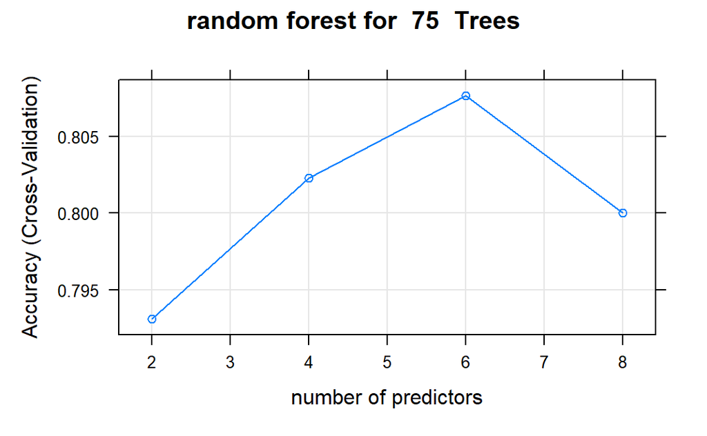

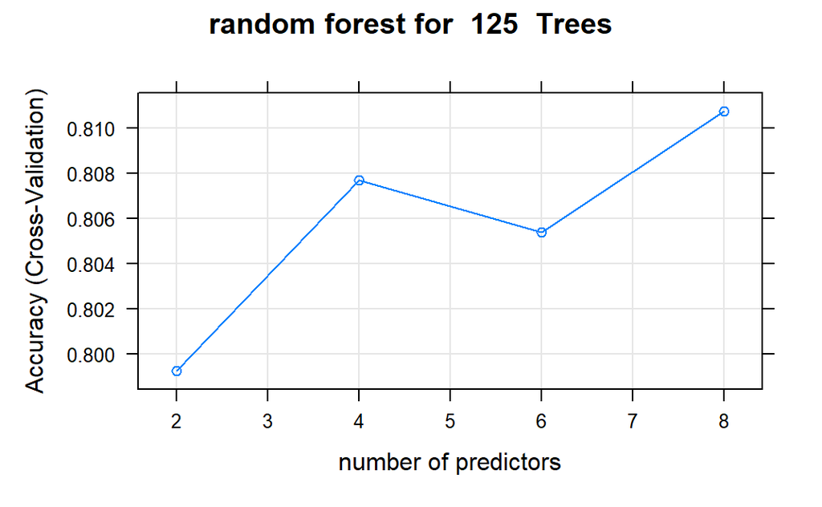

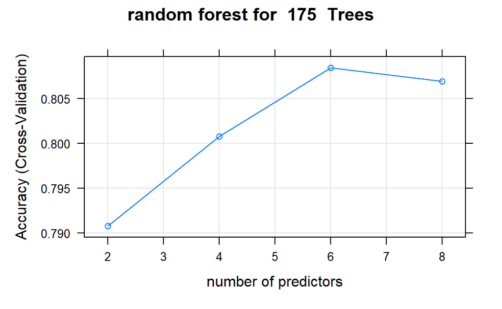

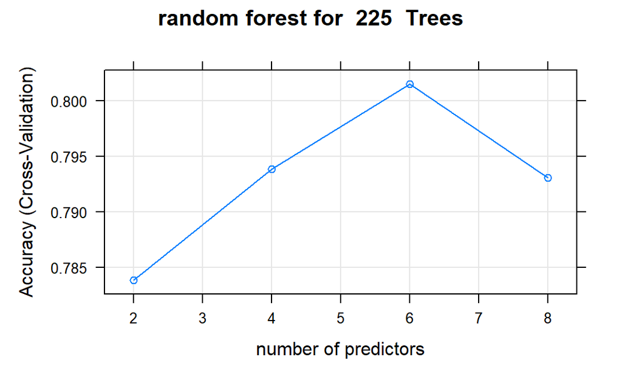

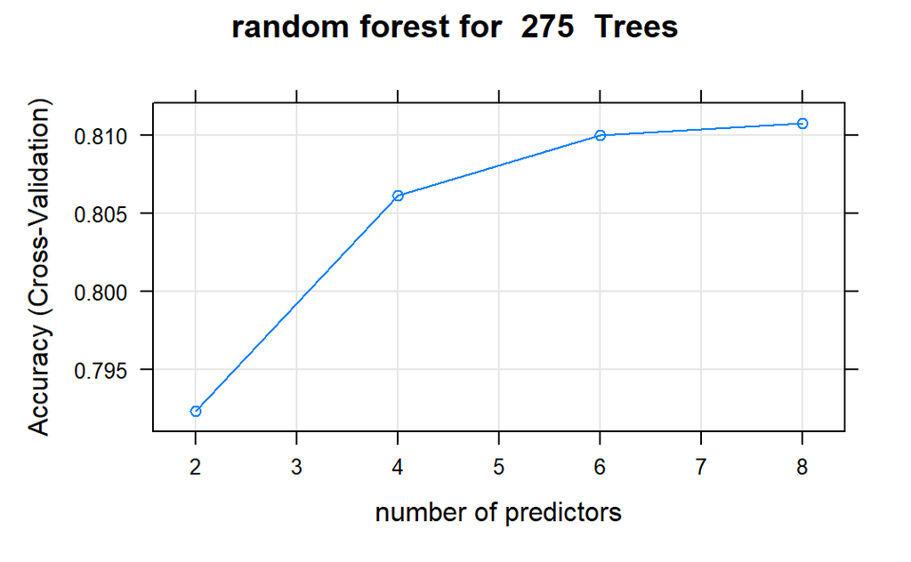

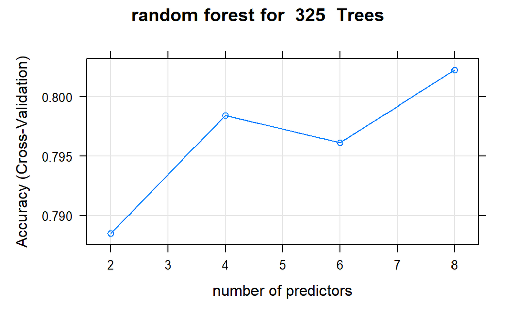

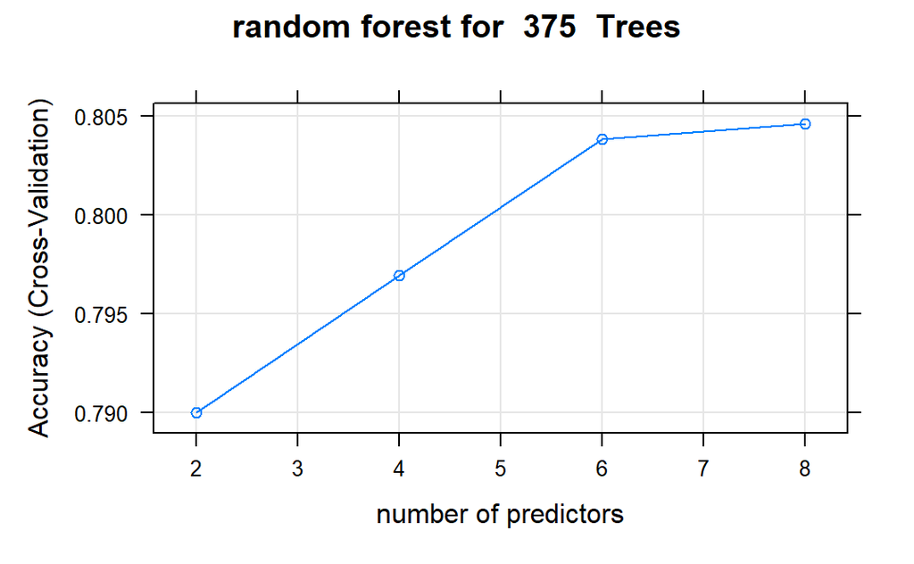

```r
for (i in 1:7)
{
  x<-x+50
  print(x)
  model<-train(V1 ~V3+V4+V5+V6+V7+V8+V9+V10+V11+V12+V13+V14+V15+V16+V17+V18,data=allFeats,method="rf",trControl=train_control,   tuneGrid=tune_grid,ntree=x)
  print(model)
  print(plot((model),main=paste("random forest for ",x," Trees"),xlab="number of predictors"))
  results<-rbind(results,model$results$Accuracy)

}
```

```r
colnames(results)<-c(2,4,6,8)
rownames(results)<-c('',25,75,125,175,225,275,325,375)
print(results)
```

```
            2         4         6         8
           NA        NA        NA        NA
25  0.7638462 0.7700000 0.7869231 0.7723077
75  0.7930769 0.8023077 0.8076923 0.8000000
125 0.7992308 0.8076923 0.8053846 0.8107692
175 0.7907692 0.8007692 0.8084615 0.8069231
225 0.7838462 0.7938462 0.8015385 0.7930769
275 0.7923077 0.8061538 0.8100000 0.8107692
325 0.7884615 0.7984615 0.7961538 0.8023077
375 0.7900000 0.7969231 0.8038462 0.8046154
```

For 3.1 I performed random forest classification with 5 fold cv. I first split the allFeautres dataframe into 5 folds, to perform 5 fold cv. I use expand.grid mtry to get number of predictors {2,4,6,8} and then outside loop train the model with the expand grid for 25, then use a loop to do this for 75 to 375 with 50 iterations for each, I then saved the accuracies of each random forest model onto a dataframe as you can see above. To add I have created a scatter graph for each value of k, this is a good visualization for each value of k as it clear shows which number of predictors are best for each k. The best value of k was 125 when it had 8 predictors with 0.8107692 (8 for =275 is also 0.8107692 but on average k=125 has better accuracies on average). This tells us that clearly 125 is the best value of k to predict what symbol the image is or not. On average between all values of k 25 has the worst accuracies, it also has the lowest accuracies when number of predictors = 2 with 0.7638462. A trend for all values of K is that when the number of predictors is 2, it gives the lowest accuracy, this is because it considers only 2 features meaning it would be harder to differ between letters and non letters with less features considered. And as the number of predictors increases the values tend to increase, this is because the it is easier to tell the difference between images if there is more features considered, however for some nTrees it doesn’t, this may be that too many features are considered here and the model becomes overfitted, e.g. 175, number of predictors=6 accuracy is 0.8084615 and when it is 8 accuracy is 0.8069231. To add the best nTrees seem to be in the middle, with them getting, with smaller and larger nTrees having slightly less accruacies, this is probably because too little trees are considered at start, e.g. 25, With a lower number of trees the model is more specific and fails to generalize,therfore this causes overfitting ,and too many at end e.g 325 and 375, this is because when the nTrees value increases the model becomes too generalized and fails to accurately data points in both the training and test sets.This is under fitting, the values in the middle have the best balance of these, therfore giving them the best accuracies. To conclude nTree=125 and No of predictor=8 is the best value for accuracy and will be used for analysis in 3.2

## Section 3.2

```r
set.seed(42)
accs<-c()
for (i in 1:15)
{
  tune_grid <-expand.grid( .mtry=8)
  model<-train(V1 ~V3+V4+V5+V6+V7+V8+V9+V10+V11+V12+V13+V14+V15+V16+V17+V18,data=allFeats,method="rf",trControl=train_control,   tuneGrid=tune_grid,ntree=125)
  print(model)
accs<-append(accs,model$results$Accuracy)
  #accs<-c(accs+model$results$Accuracy)
}
```

```
Random Forest

1300 samples
  16 predictor
  13 classes: 'a', 'b', 'c', 'd', 'e', 'f', 'g', 'h', 'i', 'j', 'sad', 'smiley', 'xclaim'

No pre-processing
Resampling: Cross-Validated (5 fold)
Summary of sample sizes: 1040, 1040, 1040, 1040, 1040
Resampling results:

  Accuracy   Kappa
  0.8046154  0.7883333

Tuning parameter 'mtry' was held constant at a value of 8
Random Forest

1300 samples
  16 predictor
  13 classes: 'a', 'b', 'c', 'd', 'e', 'f', 'g', 'h', 'i', 'j', 'sad', 'smiley', 'xclaim'

No pre-processing
Resampling: Cross-Validated (5 fold)
Summary of sample sizes: 1040, 1040, 1040, 1040, 1040
Resampling results:

  Accuracy   Kappa
  0.7961538  0.7791667

Tuning parameter 'mtry' was held constant at a value of 8
Random Forest

1300 samples
  16 predictor
  13 classes: 'a', 'b', 'c', 'd', 'e', 'f', 'g', 'h', 'i', 'j', 'sad', 'smiley', 'xclaim'

No pre-processing
Resampling: Cross-Validated (5 fold)
Summary of sample sizes: 1040, 1040, 1040, 1040, 1040
Resampling results:
```

[output cut: 170 more lines]

```
Random Forest

1300 samples
  16 predictor
  13 classes: 'a', 'b', 'c', 'd', 'e', 'f', 'g', 'h', 'i', 'j', 'sad', 'smiley', 'xclaim'

No pre-processing
Resampling: Cross-Validated (5 fold)
Summary of sample sizes: 1040, 1040, 1040, 1040, 1040
Resampling results:

  Accuracy   Kappa
  0.7846154  0.7666667

Tuning parameter 'mtry' was held constant at a value of 8
```

```r
print(accs)
```

```
 [1] 0.8046154 0.7961538 0.7838462 0.7984615 0.8007692
 [6] 0.8015385 0.8023077 0.7930769 0.7953846 0.7992308
[11] 0.8015385 0.8015385 0.7930769 0.8115385 0.7846154
```

```r
accMean<-mean(accs)
accSd<-sd(accs)
accMean
```

```
[1] 0.7978462
```

```r
accSd
```

```
[1] 0.007223049
```

```r
t.test(accs,mu = 1/13, alternative = "two.sided")
```

```
    One Sample t-test

data:  accs
t = 386.56, df = 14, p-value < 2.2e-16
alternative hypothesis: true mean is not equal to 0.07692308
95 percent confidence interval:
 0.7938462 0.8018461
sample estimates:
mean of x
0.7978462
```

In this section, I reran the best combination of trees and predictors (nTree=125 and No Of predictors=8) 15 times to check if it performs significantly better than chance. I did this by having a for loop for 15 times performing random forest for nTree=125 and No Of predictors=8 and saving the accuracy into a data frame. I then used mean function to get the mean of the 15 accuracies and sd function to get the standard deviation. The mean was 0.7978462 and the standard deviation was 0.007223049. This standard deviation score tells us that the data is clustered around the mean, which tells us that there is not distance between each model fitting, so even though there is an element of randmominess in each model fitting the difference is so slight and therefore this supports that this model performs better than chance. The mean is 0.7978462, which is down from 0.8107692 that this model got for accuracy in the results for 3.1, This tells us that this model performed slightly better than on average due the the randominess of cross validation and random forest. The t-test results will tell us if it performs better than chance or not. In this t-test we check if the accuracies are equal to the probabilty of chance which is 1/13(13 groups), if the p score is > 5% the null hypothesis (they are equal stands), if it is less, the alternative hypothesis is true (they are not equal), here the p value is 2.2e-16, which is a very small value and way less than 5%, therefore the alternative hypothesis is true and they differ a lot, as the p value is very small, to add the t value supports this as, the bigger the t value the bigger difference between the groups, the t value is positive and is 386.56, which is a big score which tells us that this model performs way better than random chance . Therefore it is clear based off mean, standard deviation and t test (p and t score) that this model performs significantly better than chance.